# project_2

```python
import pandas as pd
import numpy as np
import seaborn as sns
import matplotlib.pyplot as plt
from sklearn.model_selection import train_test_split
from sklearn.neighbors import KNeighborsClassifier
from sklearn.model_selection import KFold, GridSearchCV
from scipy.stats import zscore
from sklearn.metrics import accuracy_score
from sklearn import metrics
from sklearn.linear_model import LogisticRegression
from sklearn.model_selection import GridSearchCV
```

**Part 1. 1 a - Read all the 3 CSV files as DataFrame and store them into 3 separate variables.**

```python
normal = pd.read_csv("/kaggle/input/gl-project-2/Normal.csv")
typeh = pd.read_csv("/kaggle/input/gl-project-2/Type_H.csv")
types = pd.read_csv("/kaggle/input/gl-project-2/Type_S.csv")
```

**Part 1.1 b - Print Shape and columns of all the 3 DataFrames**

Shapes

```python
normal.shape
```

```
(100, 7)
```

```python
typeh.shape
```

```
(60, 7)
```

```python
types.shape
```

```
(150, 7)
```

Columns

```python
normal.columns
```

```
Index(['P_incidence', 'P_tilt', 'L_angle', 'S_slope', 'P_radius', 'S_Degree',
       'Class'],
      dtype='object')
```

```python
typeh.columns
```

```
Index(['P_incidence', 'P_tilt', 'L_angle', 'S_slope', 'P_radius', 'S_Degree',
       'Class'],
      dtype='object')
```

```python
types.columns
```

```
Index(['P_incidence', 'P_tilt', 'L_angle', 'S_slope', 'P_radius', 'S_Degree',
       'Class'],
      dtype='object')
```

**Part 1.1 c - Compare Column names of all the 3 DataFrames and clearly write observations**

Columns in all the three csv are **same name** with **same data types**

Columns:

P_incidence float64

P_tilt float64

L_angle float64

S_slope float64

P_radius float64

S_Degree float64

Class object

**Part 1.1 d - Print DataTypes of all the 3 DataFrames**

```python
normal.head()
```

|  | P_incidence | P_tilt | L_angle | S_slope | P_radius | S_Degree | Class |
| --- | --- | --- | --- | --- | --- | --- | --- |
| 0 | 38.505273 | 16.964297 | 35.112814 | 21.540976 | 127.632875 | 7.986683 | Normal |
| 1 | 54.920858 | 18.968430 | 51.601455 | 35.952428 | 125.846646 | 2.001642 | Normal |
| 2 | 44.362490 | 8.945435 | 46.902096 | 35.417055 | 129.220682 | 4.994195 | Normal |
| 3 | 48.318931 | 17.452121 | 48.000000 | 30.866809 | 128.980308 | -0.910941 | Normal |
| 4 | 45.701789 | 10.659859 | 42.577846 | 35.041929 | 130.178314 | -3.388910 | Normal |

```python
normal.dtypes
```

```
P_incidence    float64
P_tilt         float64
L_angle        float64
S_slope        float64
P_radius       float64
S_Degree       float64
Class           object
dtype: object
```

```python
typeh.head()
```

|  | P_incidence | P_tilt | L_angle | S_slope | P_radius | S_Degree | Class |
| --- | --- | --- | --- | --- | --- | --- | --- |
| 0 | 63.027817 | 22.552586 | 39.609117 | 40.475232 | 98.672917 | -0.254400 | Type_H |
| 1 | 39.056951 | 10.060991 | 25.015378 | 28.995960 | 114.405425 | 4.564259 | Type_H |
| 2 | 68.832021 | 22.218482 | 50.092194 | 46.613539 | 105.985135 | -3.530317 | Type_H |
| 3 | 69.297008 | 24.652878 | 44.311238 | 44.644130 | 101.868495 | 11.211523 | Type_H |
| 4 | 49.712859 | 9.652075 | 28.317406 | 40.060784 | 108.168725 | 7.918501 | Type_H |

```python
typeh.dtypes
```

```
P_incidence    float64
P_tilt         float64
L_angle        float64
S_slope        float64
P_radius       float64
S_Degree       float64
Class           object
dtype: object
```

```python
types.head()
```

|  | P_incidence | P_tilt | L_angle | S_slope | P_radius | S_Degree | Class |
| --- | --- | --- | --- | --- | --- | --- | --- |
| 0 | 74.377678 | 32.053104 | 78.772013 | 42.324573 | 143.560690 | 56.125906 | Type_S |
| 1 | 89.680567 | 32.704435 | 83.130732 | 56.976132 | 129.955476 | 92.027277 | Type_S |
| 2 | 44.529051 | 9.433234 | 52.000000 | 35.095817 | 134.711772 | 29.106575 | Type_S |
| 3 | 77.690577 | 21.380645 | 64.429442 | 56.309932 | 114.818751 | 26.931841 | Type_S |
| 4 | 76.147212 | 21.936186 | 82.961502 | 54.211027 | 123.932010 | 10.431972 | Type_S |

```python
typeh.dtypes
```

```
P_incidence    float64
P_tilt         float64
L_angle        float64
S_slope        float64
P_radius       float64
S_Degree       float64
Class           object
dtype: object
```

**Part 1.1 e - Observe and share variation in ‘Class’ feature of all the 3 DaraFrames**

```python
normal["Class"].unique()
```

```
array(['Normal', 'Nrmal'], dtype=object)
```

```python
typeh["Class"].unique()
```

```
array(['Type_H', 'type_h'], dtype=object)
```

```python
types["Class"].unique()
```

```
array(['Type_S', 'tp_s'], dtype=object)
```

Each class column in 3 csv files have variations in values

1. **Normal, Nrmal** change it to Normal
2. **Type_H, type_h** change it to Type_H
3. **Type_S, tp_s** change it to Type_S

**Part 1.2 a - Unify all the variations in ‘Class’ feature for all the 3 DataFrames**

```python
normal["Class"] = normal["Class"].replace('Nrmal','Normal')
```

```python
normal["Class"].unique()
```

```
array(['Normal'], dtype=object)
```

```python
normal["Class"].count()
```

```
100
```

```python
typeh["Class"] = typeh["Class"].replace('type_h','Type_H')
```

```python
typeh["Class"].unique()
```

```
array(['Type_H'], dtype=object)
```

```python
typeh["Class"].count()
```

```
60
```

```python
types["Class"] = types["Class"].replace('tp_s','Type_S')
```

```python
types["Class"].unique()
```

```
array(['Type_S'], dtype=object)
```

```python
types["Class"].count()
```

```
150
```

Now we have cleaned the values now , Now we can infer each csv file has a single value in Class column

normal.csv = "Normal"

typeh.csv = "Type_H"

types.csv = "Type_S"

but each has different number of records/data

normal.csv = 100

typeh.csv = 60

types.csv = 150

**Part 1.2 b - Combine all the 3 DataFrames to form a single DataFram**e

```python
df = pd.concat([normal, typeh, types])
```

```python
df.reset_index()
```

|  | index | P_incidence | P_tilt | L_angle | S_slope | P_radius | S_Degree | Class |
| --- | --- | --- | --- | --- | --- | --- | --- | --- |
| 0 | 0 | 38.505273 | 16.964297 | 35.112814 | 21.540976 | 127.632875 | 7.986683 | Normal |
| 1 | 1 | 54.920858 | 18.968430 | 51.601455 | 35.952428 | 125.846646 | 2.001642 | Normal |
| 2 | 2 | 44.362490 | 8.945435 | 46.902096 | 35.417055 | 129.220682 | 4.994195 | Normal |
| 3 | 3 | 48.318931 | 17.452121 | 48.000000 | 30.866809 | 128.980308 | -0.910941 | Normal |
| 4 | 4 | 45.701789 | 10.659859 | 42.577846 | 35.041929 | 130.178314 | -3.388910 | Normal |
| ... | ... | ... | ... | ... | ... | ... | ... | ... |
| 305 | 145 | 80.111572 | 33.942432 | 85.101608 | 46.169139 | 125.593624 | 100.292107 | Type_S |
| 306 | 146 | 95.480229 | 46.550053 | 59.000000 | 48.930176 | 96.683903 | 77.283072 | Type_S |
| 307 | 147 | 74.094731 | 18.823727 | 76.032156 | 55.271004 | 128.405731 | 73.388216 | Type_S |
| 308 | 148 | 87.679087 | 20.365613 | 93.822416 | 67.313473 | 120.944829 | 76.730629 | Type_S |
| 309 | 149 | 48.259920 | 16.417462 | 36.329137 | 31.842457 | 94.882336 | 28.343799 | Type_S |

310 rows × 8 columns

```python
df.shape
```

```
(310, 7)
```

**Part 1.2 c - Print 5 random samples of this DataFrame**

```python
df.sample(5)
# Random 5
```

|  | P_incidence | P_tilt | L_angle | S_slope | P_radius | S_Degree | Class |
| --- | --- | --- | --- | --- | --- | --- | --- |
| 25 | 54.124920 | 26.650489 | 35.329747 | 27.474432 | 121.447011 | 1.571205 | Type_H |
| 33 | 38.663257 | 12.986441 | 40.000000 | 25.676816 | 124.914118 | 2.703008 | Type_H |
| 83 | 48.902904 | 5.587589 | 55.500000 | 43.315316 | 137.108289 | 19.854759 | Normal |
| 18 | 38.046551 | 8.301669 | 26.236830 | 29.744881 | 123.803413 | 3.885773 | Normal |
| 70 | 50.066786 | 9.120340 | 32.168463 | 40.946446 | 99.712453 | 26.766697 | Type_S |

```python
df.head(5)
# Top 5
```

|  | P_incidence | P_tilt | L_angle | S_slope | P_radius | S_Degree | Class |
| --- | --- | --- | --- | --- | --- | --- | --- |
| 0 | 38.505273 | 16.964297 | 35.112814 | 21.540976 | 127.632875 | 7.986683 | Normal |
| 1 | 54.920858 | 18.968430 | 51.601455 | 35.952428 | 125.846646 | 2.001642 | Normal |
| 2 | 44.362490 | 8.945435 | 46.902096 | 35.417055 | 129.220682 | 4.994195 | Normal |
| 3 | 48.318931 | 17.452121 | 48.000000 | 30.866809 | 128.980308 | -0.910941 | Normal |
| 4 | 45.701789 | 10.659859 | 42.577846 | 35.041929 | 130.178314 | -3.388910 | Normal |

**Part 1.2 d - Print Feature-wise percentage of Null values**

```python
(df.isnull().sum() / len(df)) * 100
```

```
P_incidence    0.0
P_tilt         0.0
L_angle        0.0
S_slope        0.0
P_radius       0.0
S_Degree       0.0
Class          0.0
dtype: float64
```

**Part 1.2 e - Check 5-point summary of the new DataFrame**

```python
df.describe()
```

|  | P_incidence | P_tilt | L_angle | S_slope | P_radius | S_Degree |
| --- | --- | --- | --- | --- | --- | --- |
| count | 310.000000 | 310.000000 | 310.000000 | 310.000000 | 310.000000 | 310.000000 |
| mean | 60.496653 | 17.542822 | 51.930930 | 42.953831 | 117.920655 | 26.296694 |
| std | 17.236520 | 10.008330 | 18.554064 | 13.423102 | 13.317377 | 37.559027 |
| min | 26.147921 | -6.554948 | 14.000000 | 13.366931 | 70.082575 | -11.058179 |
| 25% | 46.430294 | 10.667069 | 37.000000 | 33.347122 | 110.709196 | 1.603727 |
| 50% | 58.691038 | 16.357689 | 49.562398 | 42.404912 | 118.268178 | 11.767934 |
| 75% | 72.877696 | 22.120395 | 63.000000 | 52.695888 | 125.467674 | 41.287352 |
| max | 129.834041 | 49.431864 | 125.742385 | 121.429566 | 163.071041 | 418.543082 |

```python
df.dtypes
```

```
P_incidence    float64
P_tilt         float64
L_angle        float64
S_slope        float64
P_radius       float64
S_Degree       float64
Class           object
dtype: object
```

**Part 1.3 a - Visualize a heatmap to understand correlation between all features**

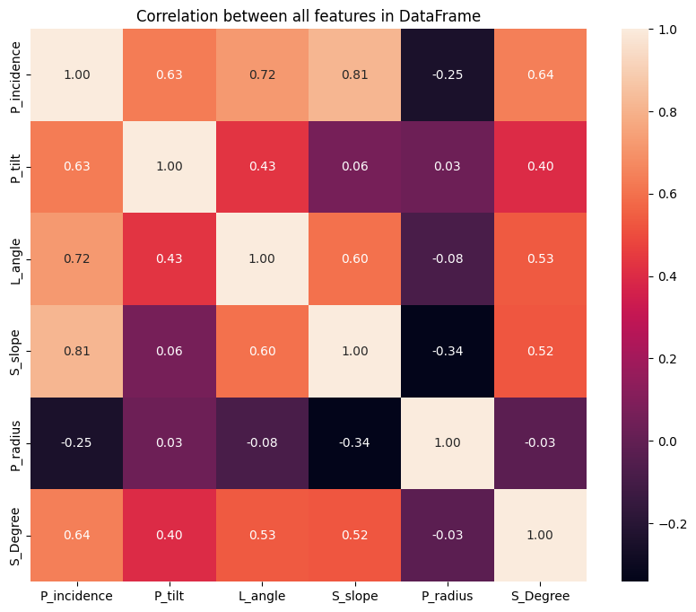

```python
correlation_matrix = df.iloc[:,:-1].corr()
plt.figure(figsize=(10, 8))
sns.heatmap(correlation_matrix, annot=True, fmt=".2f")
plt.title('Correlation between all features in DataFrame')
plt.show()
```

**Part 1.3 b - Share insights on correlation**

Lets take each feature one by one

I considered

( > 0.70 and < -0.70 => strong correlation

0.70 to 0.30 and -0.70 to -0.30 => moderate correlation

< 0.30 and < -0.30 => weak correlation )

1.P_incidence

This is strongly correlated with S_slope(0.81) and L_angle(0.72).

This is moderately correlated with S_Degree(0.64) and P_tilt(0.63).

This is Weakly correlated with P_radius(-0.25).

2.P_tilt

This is strongly correlated no other feature

This is moderately correlated with P_incidence(0.63), L_angle(0.43) and S_Degree(0.40)

This is Weakly correlated with S_slope(0.06) and P_radius(0.03)

3.L_angle

This is moderately correlated with S_slope(0.60),S_Degree(0.53) and P_tilt(0.43)

This is Weakly correlated with P_radius(-0.08)

4.S_slope

This is strongly correlated with P_incidence(0.81)

This is moderately correlated with L_angle(0.60), S_Degree(0.52) and P_radius(-0.34)

This is Weakly correlated with P_tilt(0.06)

5.P_radius

This is strongly correlated with no other feature

This is moderately correlated with S_slope(-0.34)

This is Weakly correlated with P_incidence(-0.25), P_tilt(0.03), L_angle(-0.08) and S_Degree(-0.03)

6.S_Degree

This is strongly correlated with no other feature

This is moderately correlated with P_incidence(0.64), L_angle(0.53), S_slope(0.52) and P_tilt(0.40)

This is Weakly correlated with P_radius(-0.03)

```python
df.index.duplicated()
```

[output not shown]

**Part 1.3 c - Visualize a pairplot with 3 classes distinguished by colors and share insights**

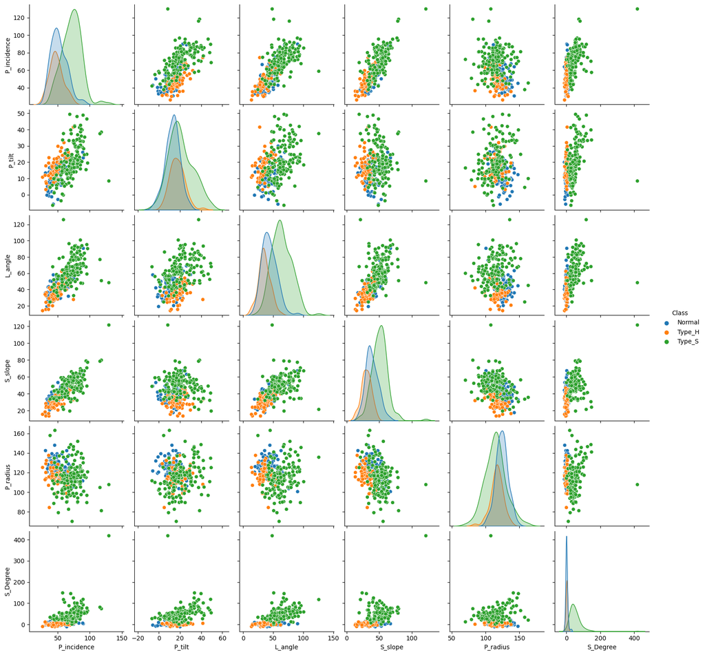

```python
sns.pairplot(df, hue ='Class')
```

Insights

Lets do feature by feature

1. P_incidence

Univariate analysis:

Here, Type_S class has near to normal distribution whereas Type_H & Normal class has right-skewed distribution

Bivariate analysis:

This has a postive correlation with P_tilt, L_angle, S_Degree and S_slope so when P_incidence increases also increasing This don't have much correlation with other features.

1. P_tilt

Univariate analysis:

Here, Normal class has near to normal distribution whereas Type_H & Type_S class has right-skewed distribution

Bivariate analysis:

This has a postive correlation with P_incidence, S_Degree so when P_tilt increases also increasing This don't have much correlation with other features.

1. L_angle

Univariate analysis:

Here, Normal,Type_H & Type_S class has right-skewed distribution

Bivariate analysis:

This has a postive correlation with P_incidence, S_Degree and S_slope so when L_angle increases also increasing This don't have much correlation with other features.

1. S_slope

Univariate analysis:

Here, Normal,Type_H & Type_S class has right-skewed distribution

Bivariate analysis:

This has a postive correlation with P_incidence, S_Degree and L_angle so when S_slope increases also increasing This don't have much correlation with other features.

1. P_radius

Univariate analysis:

Here, Normal,Type_H & Type_S class has near to normal distribution

Bivariate analysis:

This don't have much correlation with any other features.

1. S_Degree

Univariate analysis:

Here, Normal & Type_H class has near to normal distribution , Type_S class is right-skewed distribution

Bivariate analysis:

This has a postive correlation with all other features except P_radius so when S_Degree increases also increasing

**Part 1.3 d - Visualize a jointplot for ‘P_incidence’ and ‘S_slope’ and share insights**

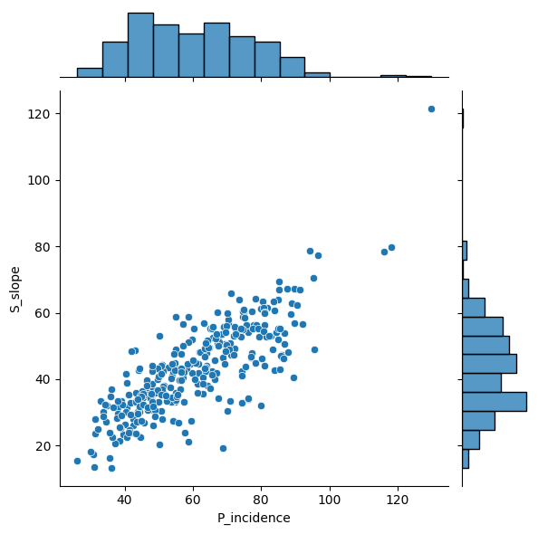

```python
sns.jointplot(x='P_incidence', y='S_slope', data=df, kind='scatter')
```

Insights

1. P_incidence and S_slope are right-skewed distribution
2. P_incidence and S_slope are positively correlated , when P_incidence increases S_slope also increases and vice versa

**Part 1.3 e - Visualize a boxplot to check distribution of the features and share insights.**

```python
df.describe()
```

|  | P_incidence | P_tilt | L_angle | S_slope | P_radius | S_Degree |
| --- | --- | --- | --- | --- | --- | --- |
| count | 310.000000 | 310.000000 | 310.000000 | 310.000000 | 310.000000 | 310.000000 |
| mean | 60.496653 | 17.542822 | 51.930930 | 42.953831 | 117.920655 | 26.296694 |
| std | 17.236520 | 10.008330 | 18.554064 | 13.423102 | 13.317377 | 37.559027 |
| min | 26.147921 | -6.554948 | 14.000000 | 13.366931 | 70.082575 | -11.058179 |
| 25% | 46.430294 | 10.667069 | 37.000000 | 33.347122 | 110.709196 | 1.603727 |
| 50% | 58.691038 | 16.357689 | 49.562398 | 42.404912 | 118.268178 | 11.767934 |
| 75% | 72.877696 | 22.120395 | 63.000000 | 52.695888 | 125.467674 | 41.287352 |
| max | 129.834041 | 49.431864 | 125.742385 | 121.429566 | 163.071041 | 418.543082 |

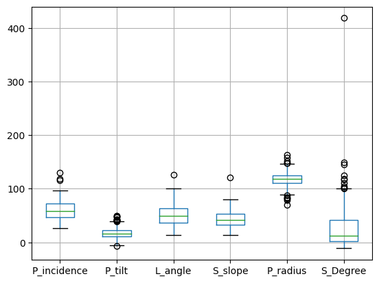

```python
df.boxplot()
```

Lets do feature by feature

1.P_incidence

The central tendency (mean is near to 60), the data spread ranges from 25 to 130 with some outliers in the top end

2.P_tilt

The central tendency (mean is near to 17), the data spread ranges from below 0 to 50 with some outliers in both top and bottom ends

3.L_angle

The central tendency (mean is near to 50), the data spread ranges from 10 to 120 with some outliers in the top

4.S_slope

The central tendency (mean is near to 40), the data spread ranges from 10 to 120 with some outliers in the top

5.P_radius

The central tendency (mean is near to 25), the data spread ranges from below 0 to above 400 with some outliers in the top end

**Part 1.4 a - Split data into X and Y**

```python
X = df.iloc[:,:-1].copy()
```

```python
X.head()
```

|  | P_incidence | P_tilt | L_angle | S_slope | P_radius | S_Degree |
| --- | --- | --- | --- | --- | --- | --- |
| 0 | 38.505273 | 16.964297 | 35.112814 | 21.540976 | 127.632875 | 7.986683 |
| 1 | 54.920858 | 18.968430 | 51.601455 | 35.952428 | 125.846646 | 2.001642 |
| 2 | 44.362490 | 8.945435 | 46.902096 | 35.417055 | 129.220682 | 4.994195 |
| 3 | 48.318931 | 17.452121 | 48.000000 | 30.866809 | 128.980308 | -0.910941 |
| 4 | 45.701789 | 10.659859 | 42.577846 | 35.041929 | 130.178314 | -3.388910 |

```python
Y = df.iloc[:,-1].copy()
```

```python
Y.head()
```

```
0    Normal
1    Normal
2    Normal
3    Normal
4    Normal
Name: Class, dtype: object
```

```python
Y.unique()
```

```
array(['Normal', 'Type_H', 'Type_S'], dtype=object)
```

```python
X  = X.apply(zscore)
```

**Part 1.4 b - Split data into train and test with 80:20 proportion**

```python
X_train, X_test, y_train, y_test = train_test_split(X, Y, test_size=0.20, random_state=1)
```

```python
X_train.shape
```

```
(248, 6)
```

```python
y_train.shape
```

```
(248,)
```

```python
X_test.shape
```

```
(62, 6)
```

```python
y_test.shape
```

```
(62,)
```

**Part 1.4 c - Train a Supervised Learning Classification base model using KNN classifier**

```python
KNN = KNeighborsClassifier(n_neighbors=5 , weights = 'distance' )
```

```python
KNN.fit(X_train, y_train)
```

```
KNeighborsClassifier(weights='distance')
```

**Part 1.4 d - Print all the possible performance metrics for both train and test data**

```python
predicted_labels_test = KNN.predict(X_test)
print("\nTest Score :")
KNN.score(X_test, y_test)
```

```
Test Score :
```

```
0.7258064516129032
```

```python
predicted_labels_train = KNN.predict(X_train)
print("\nTrain Score :")
KNN.score(X_train, y_train)
```

```
Train Score :
```

```
1.0
```

```
Confusion Matrix
```

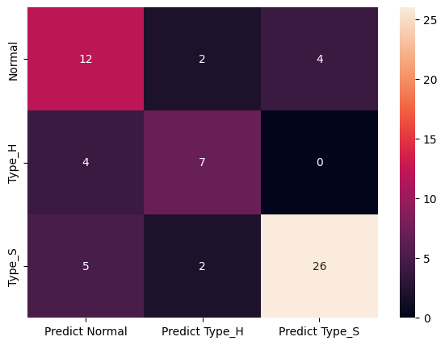

```python
from sklearn import metrics

print("Confusion Matrix")
cm=metrics.confusion_matrix(y_test, predicted_labels_test, labels=["Normal", "Type_H","Type_S"])

df_cm = pd.DataFrame(cm, index = [i for i in ["Normal", "Type_H","Type_S"]],
                  columns = [i for i in ["Predict Normal", "Predict Type_H","Predict Type_S"]])
plt.figure(figsize = (7,5))
sns.heatmap(df_cm, annot=True)
```

```python
print("Train Performance Matrix:")
metrics.classification_report(y_train, predicted_labels_train).split("\n")
```

```
Train Performance Matrix:
```

```
['              precision    recall  f1-score   support',
 '',
 '      Normal       1.00      1.00      1.00        82',
 '      Type_H       1.00      1.00      1.00        49',
 '      Type_S       1.00      1.00      1.00       117',
 '',
 '    accuracy                           1.00       248',
 '   macro avg       1.00      1.00      1.00       248',
 'weighted avg       1.00      1.00      1.00       248',
 '']
```

```python
print("Test Performance Matrix:")
metrics.classification_report(y_test, predicted_labels_test).split("\n")
```

```
Test Performance Matrix:
```

```
['              precision    recall  f1-score   support',
 '',
 '      Normal       0.57      0.67      0.62        18',
 '      Type_H       0.64      0.64      0.64        11',
 '      Type_S       0.87      0.79      0.83        33',
 '',
 '    accuracy                           0.73        62',
 '   macro avg       0.69      0.70      0.69        62',
 'weighted avg       0.74      0.73      0.73        62',
 '']
```

**Part 1.5 a - Experiment with various parameters to improve performance of the base model**

Let do hyperparamater tuning to find the best K value

```python
train_score = {}
test_score = {}
n_neighbors = np.arange(1, 50, 1)
for neighbor in n_neighbors:
    KNN = KNeighborsClassifier(n_neighbors=neighbor)
    KNN.fit(X_train, y_train)
    train_score[neighbor]=KNN.score(X_train, y_train)
    test_score[neighbor]=KNN.score(X_test, y_test)
```

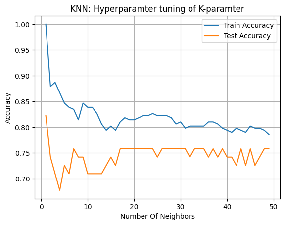

```python
plt.plot(n_neighbors, train_score.values(), label="Train Accuracy")
plt.plot(n_neighbors, test_score.values(), label="Test Accuracy")
plt.xlabel("Number Of Neighbors")
plt.ylabel("Accuracy")
plt.title("KNN: Hyperparamter tuning of K-paramter")
plt.legend()
plt.grid()
plt.show()
```

Hyperparamter is done by varing K values and found best suited K value , when k is 17 its perfoming well without overfitting and underfitting So, I am choosing K=17

**Part 1.5 b - Clearly showcase improvement in performance achieved**

```python
knn=KNeighborsClassifier(n_neighbors=17)
knn.fit(X_train, y_train)
y_pred=knn.predict(X_train)
print("Train Score:",knn.score(X_train, y_train))

y_pred=knn.predict(X_test)
print("Test Score",knn.score(X_test, y_test))
```

```
Train Score: 0.8104838709677419
Test Score 0.7580645161290323
```

```python
predicted_labels_test = knn.predict(X_test)
print("Test Performance Matrix: (After Hypertuning):")
metrics.classification_report(y_test, predicted_labels_test).split("\n")
```

```
Test Performance Matrix: (After Hypertuning):
```

```
['              precision    recall  f1-score   support',
 '',
 '      Normal       0.63      0.67      0.65        18',
 '      Type_H       0.67      0.73      0.70        11',
 '      Type_S       0.87      0.82      0.84        33',
 '',
 '    accuracy                           0.76        62',
 '   macro avg       0.72      0.74      0.73        62',
 'weighted avg       0.77      0.76      0.76        62',
 '']
```

Lets see class by class

After hyperparamtertuning

**1.Normal**

Precision - improved from 57 to 63(+10%)

**2.Type_H**

Precision - improved from 64 to 67(+4%)

Recall - improved from 64 to 73(+14%)

F1 score - improved from 64 to 70(+9%)

**3.Type_S**

Precision - no improvement same 87

Recall - improved from 79 to 82(+3%)

F1 score - improved from 83 to 84(+1%)

**Part 1.5 c - Clearly state which parameters contributed most to improve model performance.**

We used K - hyperparameter to improve the model score by hyperparamater tuning and showed the overall model improvements in 1.5b

**Part 2.1 a - Read both the Datasets ‘Data1’ and ‘Data 2’ as DataFrame and store them into two separate variables**

```python
data1 = pd.read_csv("/kaggle/input/glproj2data2/Data1.csv")
data2 = pd.read_csv("/kaggle/input/glproj2data2/Data2.csv")
```

```python
data1.head()
```

|  | ID | Age | CustomerSince | HighestSpend | ZipCode | HiddenScore | MonthlyAverageSpend | Level |
| --- | --- | --- | --- | --- | --- | --- | --- | --- |
| 0 | 1 | 25 | 1 | 49 | 91107 | 4 | 1.6 | 1 |
| 1 | 2 | 45 | 19 | 34 | 90089 | 3 | 1.5 | 1 |
| 2 | 3 | 39 | 15 | 11 | 94720 | 1 | 1.0 | 1 |
| 3 | 4 | 35 | 9 | 100 | 94112 | 1 | 2.7 | 2 |
| 4 | 5 | 35 | 8 | 45 | 91330 | 4 | 1.0 | 2 |

```python
data2.head()
```

|  | ID | Mortgage | Security | FixedDepositAccount | InternetBanking | CreditCard | LoanOnCard |
| --- | --- | --- | --- | --- | --- | --- | --- |
| 0 | 1 | 0 | 1 | 0 | 0 | 0 | NaN |
| 1 | 2 | 0 | 1 | 0 | 0 | 0 | NaN |
| 2 | 3 | 0 | 0 | 0 | 0 | 0 | NaN |
| 3 | 4 | 0 | 0 | 0 | 0 | 0 | NaN |
| 4 | 5 | 0 | 0 | 0 | 0 | 1 | NaN |

**Part 2.1 b - Print shape and Column Names and DataTypes of both the Dataframes.**

```python
data1.shape
```

```
(5000, 8)
```

```python
data1.columns
```

```
Index(['ID', 'Age', 'CustomerSince', 'HighestSpend', 'ZipCode', 'HiddenScore',
       'MonthlyAverageSpend', 'Level'],
      dtype='object')
```

```python
data2.shape
```

```
(5000, 7)
```

```python
data2.columns
```

```
Index(['ID', 'Mortgage', 'Security', 'FixedDepositAccount', 'InternetBanking',
       'CreditCard', 'LoanOnCard'],
      dtype='object')
```

**Part 2.1 c - Merge both the Dataframes on ‘ID’ feature to form a single DataFrame**

```python
data = pd.merge(data1, data2, on='ID')
```

```python
data.shape
```

```
(5000, 14)
```

```python
data.columns
```

```
Index(['ID', 'Age', 'CustomerSince', 'HighestSpend', 'ZipCode', 'HiddenScore',
       'MonthlyAverageSpend', 'Level', 'Mortgage', 'Security',
       'FixedDepositAccount', 'InternetBanking', 'CreditCard', 'LoanOnCard'],
      dtype='object')
```

```python
data.head()
```

|  | ID | Age | CustomerSince | HighestSpend | ZipCode | HiddenScore | MonthlyAverageSpend | Level | Mortgage | Security | FixedDepositAccount | InternetBanking | CreditCard | LoanOnCard |
| --- | --- | --- | --- | --- | --- | --- | --- | --- | --- | --- | --- | --- | --- | --- |
| 0 | 1 | 25 | 1 | 49 | 91107 | 4 | 1.6 | 1 | 0 | 1 | 0 | 0 | 0 | NaN |
| 1 | 2 | 45 | 19 | 34 | 90089 | 3 | 1.5 | 1 | 0 | 1 | 0 | 0 | 0 | NaN |
| 2 | 3 | 39 | 15 | 11 | 94720 | 1 | 1.0 | 1 | 0 | 0 | 0 | 0 | 0 | NaN |
| 3 | 4 | 35 | 9 | 100 | 94112 | 1 | 2.7 | 2 | 0 | 0 | 0 | 0 | 0 | NaN |
| 4 | 5 | 35 | 8 | 45 | 91330 | 4 | 1.0 | 2 | 0 | 0 | 0 | 0 | 1 | NaN |

```python
data.dtypes
```

```
ID                       int64
Age                      int64
CustomerSince            int64
HighestSpend             int64
ZipCode                  int64
HiddenScore              int64
MonthlyAverageSpend    float64
Level                    int64
Mortgage                 int64
Security                 int64
FixedDepositAccount      int64
InternetBanking          int64
CreditCard               int64
LoanOnCard             float64
dtype: object
```

```python
cols = ["CreditCard", "InternetBanking", "FixedDepositAccount", "Security", "Level", "HiddenScore"]
```

```python
cols
```

```
['CreditCard',
 'InternetBanking',
 'FixedDepositAccount',
 'Security',
 'Level',
 'HiddenScore']
```

To check what are all the values we have in these ‘CreditCard’, ‘InternetBanking’, ‘FixedDepositAccount’, ‘Security’, ‘Level’, ‘HiddenScore’. columns

```python
for i in data.columns:
    if i in cols:
        print(data[i].unique())
```

```
[4 3 1 2]
[1 2 3]
[1 0]
[0 1]
[0 1]
[0 1]
```

```python
for i in data.columns:
    if i in cols:
        data[i] = data[i].astype(str)
```

**Part 2.1 d - Change Datatype of below features to ‘Object’**

```python
data.dtypes
```

```
ID                       int64
Age                      int64
CustomerSince            int64
HighestSpend             int64
ZipCode                  int64
HiddenScore             object
MonthlyAverageSpend    float64
Level                   object
Mortgage                 int64
Security                object
FixedDepositAccount     object
InternetBanking         object
CreditCard              object
LoanOnCard             float64
dtype: object
```

All the mentioned columns are changed to object type

**Part 2.2 a - Visualize distribution of Target variable ‘LoanOnCard’ and clearly share insights**

```python
data["LoanOnCard"].unique()
```

```
array([nan,  1.,  0.])
```

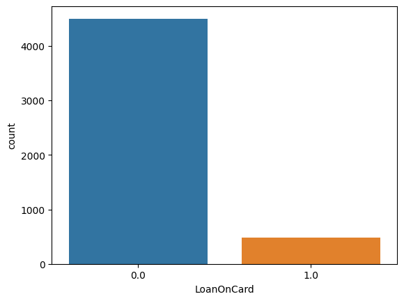

```python
sns.countplot(data=data, x='LoanOnCard')
```

```python
data["LoanOnCard"].value_counts(dropna=False)
```

```
LoanOnCard
0.0    4500
1.0     480
NaN      20
Name: count, dtype: int64
```

**Insights**

Overall, we have 5000 observation

We have two classes in target variable (0 and 1)

class 0 - has 4500 (90%)

class 1 - has 480 (9.6%)

null values - 20 (0.4%)

We have more data for class 0 and very less data in class 1 , this seems to be a class imbalance issue.

**Part 2.2 b - Check the percentage of missing values and impute if required**

```python
(data["LoanOnCard"].value_counts(dropna=False)/5000)*100
```

```
LoanOnCard
0.0    90.0
1.0     9.6
NaN     0.4
Name: count, dtype: float64
```

Lets impute the NaN value with the mode since its a categorical column

```python
mode_value = data['LoanOnCard'].mode()[0]
```

```python
mode_value
```

```
0.0
```

```python
data['LoanOnCard'].fillna(mode_value, inplace=True)
```

```python
data["LoanOnCard"].value_counts()
```

```
LoanOnCard
0.0    4520
1.0     480
Name: count, dtype: int64
```

**Part 2.2 c - Check for unexpected values in each categorical variable and impute with best suitable value**

```python
data.select_dtypes(include='object').dtypes
```

```
HiddenScore            object
Level                  object
Security               object
FixedDepositAccount    object
InternetBanking        object
CreditCard             object
dtype: object
```

```python
data["HiddenScore"].unique()
```

```
array(['4', '3', '1', '2'], dtype=object)
```

```python
data["Level"].unique()
```

```
array(['1', '2', '3'], dtype=object)
```

```python
data["Security"].unique()
```

```
array(['1', '0'], dtype=object)
```

```python
data["FixedDepositAccount"].unique()
```

```
array(['0', '1'], dtype=object)
```

```python
data["InternetBanking"].unique()
```

```
array(['0', '1'], dtype=object)
```

```python
data["CreditCard"].unique()
```

```
array(['0', '1'], dtype=object)
```

```python
data["LoanOnCard"].unique()
```

```
array([0., 1.])
```

```python
# Round off the target variable to have 0/1
data["LoanOnCard"] = data["LoanOnCard"].astype(int)
data["LoanOnCard"] = data["LoanOnCard"].astype(str)
```

```python
data["LoanOnCard"].unique()
```

```
array(['0', '1'], dtype=object)
```

Now, all categorical columns have proper labels 0/1 or proper multiclass labels like 1,2 3,etc..

**Part 2.3 a- Split data into X and Y**

```python
df = data.copy()
```

```python
df.head()
```

|  | ID | Age | CustomerSince | HighestSpend | ZipCode | HiddenScore | MonthlyAverageSpend | Level | Mortgage | Security | FixedDepositAccount | InternetBanking | CreditCard | LoanOnCard |
| --- | --- | --- | --- | --- | --- | --- | --- | --- | --- | --- | --- | --- | --- | --- |
| 0 | 1 | 25 | 1 | 49 | 91107 | 4 | 1.6 | 1 | 0 | 1 | 0 | 0 | 0 | 0 |
| 1 | 2 | 45 | 19 | 34 | 90089 | 3 | 1.5 | 1 | 0 | 1 | 0 | 0 | 0 | 0 |
| 2 | 3 | 39 | 15 | 11 | 94720 | 1 | 1.0 | 1 | 0 | 0 | 0 | 0 | 0 | 0 |
| 3 | 4 | 35 | 9 | 100 | 94112 | 1 | 2.7 | 2 | 0 | 0 | 0 | 0 | 0 | 0 |
| 4 | 5 | 35 | 8 | 45 | 91330 | 4 | 1.0 | 2 | 0 | 0 | 0 | 0 | 1 | 0 |

```python
df = df.drop(columns=["ID","ZipCode"])
```

```python
df.head()
```

|  | Age | CustomerSince | HighestSpend | HiddenScore | MonthlyAverageSpend | Level | Mortgage | Security | FixedDepositAccount | InternetBanking | CreditCard | LoanOnCard |
| --- | --- | --- | --- | --- | --- | --- | --- | --- | --- | --- | --- | --- |
| 0 | 25 | 1 | 49 | 4 | 1.6 | 1 | 0 | 1 | 0 | 0 | 0 | 0 |
| 1 | 45 | 19 | 34 | 3 | 1.5 | 1 | 0 | 1 | 0 | 0 | 0 | 0 |
| 2 | 39 | 15 | 11 | 1 | 1.0 | 1 | 0 | 0 | 0 | 0 | 0 | 0 |
| 3 | 35 | 9 | 100 | 1 | 2.7 | 2 | 0 | 0 | 0 | 0 | 0 | 0 |
| 4 | 35 | 8 | 45 | 4 | 1.0 | 2 | 0 | 0 | 0 | 0 | 1 | 0 |

```python
X = df.iloc[:,:-1]
Y = df.iloc[:,-1]
```

```python
X.head()
```

|  | Age | CustomerSince | HighestSpend | HiddenScore | MonthlyAverageSpend | Level | Mortgage | Security | FixedDepositAccount | InternetBanking | CreditCard |
| --- | --- | --- | --- | --- | --- | --- | --- | --- | --- | --- | --- |
| 0 | 25 | 1 | 49 | 4 | 1.6 | 1 | 0 | 1 | 0 | 0 | 0 |
| 1 | 45 | 19 | 34 | 3 | 1.5 | 1 | 0 | 1 | 0 | 0 | 0 |
| 2 | 39 | 15 | 11 | 1 | 1.0 | 1 | 0 | 0 | 0 | 0 | 0 |
| 3 | 35 | 9 | 100 | 1 | 2.7 | 2 | 0 | 0 | 0 | 0 | 0 |
| 4 | 35 | 8 | 45 | 4 | 1.0 | 2 | 0 | 0 | 0 | 0 | 1 |

```python
Y.head()
```

```
0    0
1    0
2    0
3    0
4    0
Name: LoanOnCard, dtype: object
```

**Part 2.3 b - Split data into train and test. Keep 25% data reserved for testing**

```python
X_train, X_test, y_train, y_test = train_test_split(X, Y, test_size=0.25, random_state=1)
```

```python
X_train.shape
```

```
(3750, 11)
```

```python
X_test.shape
```

```
(1250, 11)
```

**Part 2.3 c - Train a Supervised Learning Classification base model - Logistic Regression**

```python
model = LogisticRegression(solver="liblinear")
model.fit(X_train, y_train)
```

```
LogisticRegression(solver='liblinear')
```

**Part 2.3 d - Print evaluation metrics for the model and clearly share insights**

```python
model_score = model.score(X_test, y_test)
print("Test score: ",model_score)
model_score = model.score(X_train, y_train)
print("Train score: ",model_score)
```

```
Test score:  0.9448
Train score:  0.9517333333333333
```

```python
y_predict = model.predict(X_test)
```

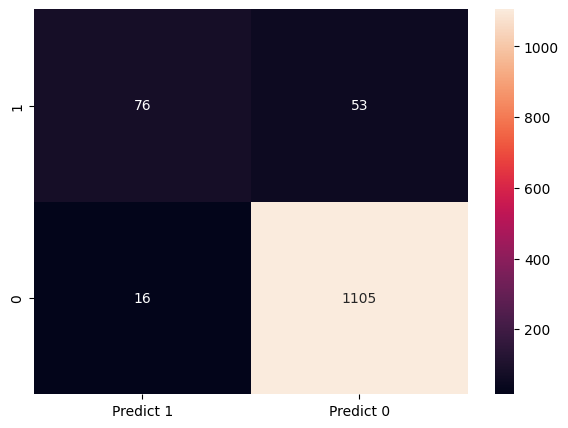

```python
cm=metrics.confusion_matrix(y_test, y_predict, labels=["1","0"])

df_cm = pd.DataFrame(cm, index = [i for i in ["1","0"]],
                  columns = [i for i in ["Predict 1","Predict 0"]])
plt.figure(figsize = (7,5))
sns.heatmap(df_cm, annot=True,fmt='.0f')
```

The confusion matrix

True Positives (TP): we correctly predicted that they do get loan 76

True Negatives (TN): we correctly predicted that they don't get loan 1105

False Positives (FP): we incorrectly predicted that they do get loan 16 Falsely

False Negatives (FN): we incorrectly predicted that they don't get loan 53 Falsely

```python
print("Test Performance Matrix: (Log reg - base model):")
metrics.classification_report(y_test, y_predict).split("\n")
```

```
Test Performance Matrix: (Log reg - base model):
```

```
['              precision    recall  f1-score   support',
 '',
 '           0       0.95      0.99      0.97      1121',
 '           1       0.83      0.59      0.69       129',
 '',
 '    accuracy                           0.94      1250',
 '   macro avg       0.89      0.79      0.83      1250',
 'weighted avg       0.94      0.94      0.94      1250',
 '']
```

Metrics

Class 0

Precsion - correct class 0 predictions to overall class 0 predictions = 95

Recall - correct class 0 predictions to overall class 0 observations = 99

F1 - normalised of Precision of Recall = 97

Class 1

Precsion - correct class 1 predictions to overall class 1 predictions = 83

Recall - correct class 1 predictions to overall class 1 observations = 59

F1 - normalised of Precision of Recall = 69

**Part 2.3 e - Balance the data using the right balancing technique.**

```python
y_train.value_counts()
```

```
LoanOnCard
0    3399
1     351
Name: count, dtype: int64
```

```python
from imblearn.over_sampling import RandomOverSampler
oversampler = RandomOverSampler(random_state=42)
X_train_resampled, y_train_resampled = oversampler.fit_resample(X_train, y_train)
```

```python
y_train_resampled.value_counts()
```

```
LoanOnCard
0    3399
1    3399
Name: count, dtype: int64
```

Now , we have sampled and made the class 0 and class 1 = 50 : 50, we did this only in training data and not in testing data to test it with real data

**Part 2.3 f- Again train the same previous model on balanced data**

```python
model_s = LogisticRegression(solver="liblinear")
model_s.fit(X_train_resampled, y_train_resampled)
```

```
LogisticRegression(solver='liblinear')
```

**Part 2.3 g- Print evaluation metrics and clearly share differences observed**

```python
model_score = model_s.score(X_test, y_test)
print("Test score: (After sampling)",model_score)
model_score = model_s.score(X_train_resampled, y_train_resampled)
print("Train score: (After sampling)",model_score)
```

```
Test score: (After sampling) 0.8888
Train score: (After sampling) 0.9042365401588702
```

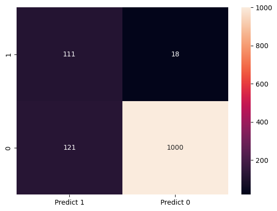

```python
y_predict_ = model_s.predict(X_test)
cm=metrics.confusion_matrix(y_test, y_predict_, labels=["1","0"])

df_cm = pd.DataFrame(cm, index = [i for i in ["1","0"]],
                  columns = [i for i in ["Predict 1","Predict 0"]])
plt.figure(figsize = (7,5))
sns.heatmap(df_cm, annot=True,fmt='.0f')
```

The confusion matrix after sampling

True Positives (TP): we correctly predicted that they do get loan 111(increased from 76)

True Negatives (TN): we correctly predicted that they don't get loan 1000(decreased from 1105)

False Positives (FP): we incorrectly predicted that they do get loan 121 Falsely(increased from 16)

False Negatives (FN): we incorrectly predicted that they don't get loan 18 Falsely(decreased from 53)

```python
print("Test Performance Matrix: (Log reg - base model after sampling):")
metrics.classification_report(y_test, y_predict_).split("\n")
```

```
Test Performance Matrix: (Log reg - base model after sampling):
```

```
['              precision    recall  f1-score   support',
 '',
 '           0       0.98      0.89      0.94      1121',
 '           1       0.48      0.86      0.61       129',
 '',
 '    accuracy                           0.89      1250',
 '   macro avg       0.73      0.88      0.77      1250',
 'weighted avg       0.93      0.89      0.90      1250',
 '']
```

**Metrics after sampling**

**Class 0**

Precsion - correct class 0 predictions to overall class 0 predictions = 98 (increased from 95)

Recall - correct class 0 predictions to overall class 0 observations = 89 (decreased from 99)

F1 - normalised of Precision of Recall = 94 (decreased from 97)

**Class 1**

Recall - correct class 1 predictions to overall class 1 observations = 86 (increased from 59)

F1 - normalised of Precision of Recall = 61 (decreased from 69)

**Part 2.4 a- Train a base model each for SVM, KNN**

```python
# Scaling the data for SVM and KNN algo
from sklearn.preprocessing import StandardScaler
scaler = StandardScaler()
numerical_columns = X_train.select_dtypes(include=['int', 'float']).columns
categorical_columns = X_train.select_dtypes(include=['object', 'category']).columns




X_train_resampled[numerical_columns] = scaler.fit_transform(X_train_resampled[numerical_columns])
X_test[numerical_columns] = scaler.fit_transform(X_test[numerical_columns])


# X_train_resampled  = X_train_resampled.apply(zscore)
# X_test  = X_train_resampled.apply(zscore)
```

```python
X_train_resampled.head()
```

|  | Age | CustomerSince | HighestSpend | HiddenScore | MonthlyAverageSpend | Level | Mortgage | Security | FixedDepositAccount | InternetBanking | CreditCard |
| --- | --- | --- | --- | --- | --- | --- | --- | --- | --- | --- | --- |
| 0 | -0.347901 | -0.328009 | -0.142185 | 3 | -0.864011 | 1 | 1.664477 | 0 | 0 | 0 | 0 |
| 1 | 1.020602 | 1.039498 | 1.103282 | 4 | -0.077574 | 3 | -0.578379 | 0 | 0 | 1 | 0 |
| 2 | 0.592945 | 0.697621 | 0.805857 | 2 | 1.819128 | 1 | -0.578379 | 0 | 0 | 1 | 0 |
| 3 | -1.203215 | -1.097232 | -1.778023 | 1 | -1.095316 | 3 | 0.035376 | 0 | 0 | 1 | 0 |
| 4 | 1.362728 | 1.295905 | 0.136651 | 2 | -0.031313 | 1 | -0.578379 | 0 | 0 | 0 | 0 |

```python
X_test.head()
```

|  | Age | CustomerSince | HighestSpend | HiddenScore | MonthlyAverageSpend | Level | Mortgage | Security | FixedDepositAccount | InternetBanking | CreditCard |
| --- | --- | --- | --- | --- | --- | --- | --- | --- | --- | --- | --- |
| 2764 | -1.244625 | -1.314406 | 0.194385 | 1 | 0.525356 | 3 | 0.429588 | 0 | 0 | 0 | 1 |
| 4767 | -0.891680 | -0.960957 | -0.648175 | 3 | -0.601960 | 1 | 0.392122 | 1 | 0 | 0 | 0 |
| 3814 | -0.979917 | -0.960957 | -0.864216 | 3 | -0.376497 | 1 | -0.553902 | 0 | 0 | 0 | 0 |
| 3499 | 0.343627 | 0.276114 | 0.842508 | 1 | -0.940155 | 1 | 2.124938 | 0 | 0 | 1 | 0 |
| 2735 | -0.803444 | -0.695870 | -0.108072 | 3 | 0.356259 | 2 | 0.991583 | 0 | 0 | 1 | 0 |

```python
# KNN base model
KNN = KNeighborsClassifier(n_neighbors=5 , weights = 'distance' )
KNN.fit(X_train_resampled, y_train_resampled)
print("\nTest Score (KNN base model):")
print(KNN.score(X_test, y_test))
print("\nTrain Score (KNN base model):")
print(KNN.score(X_train_resampled, y_train_resampled))
print("Test Performance Matrix:")
predicted_labels_test = KNN.predict(X_test)
metrics.classification_report(y_test, predicted_labels_test).split("\n")
```

```
Test Score (KNN base model):
0.8608

Train Score (KNN base model):
1.0
Test Performance Matrix:
```

```
['              precision    recall  f1-score   support',
 '',
 '           0       0.99      0.85      0.92      1121',
 '           1       0.42      0.95      0.58       129',
 '',
 '    accuracy                           0.86      1250',
 '   macro avg       0.71      0.90      0.75      1250',
 'weighted avg       0.93      0.86      0.88      1250',
 '']
```

```python
# SVM algo base model
from sklearn import svm

clf = svm.SVC(gamma=0.025, C=3)
clf.fit(X_train_resampled , y_train_resampled)
print("\nTest Score (SVM base model):")
print(clf.score(X_test, y_test))
print("\nTrain Score (SVM base model):")
print(clf.score(X_train_resampled, y_train_resampled))
print("Test Performance Matrix:")
predicted_labels_test = clf.predict(X_test)
metrics.classification_report(y_test, predicted_labels_test).split("\n")
```

```
Test Score (SVM base model):
0.8024

Train Score (SVM base model):
0.9646954986760812
Test Performance Matrix:
```

```
['              precision    recall  f1-score   support',
 '',
 '           0       0.99      0.79      0.88      1121',
 '           1       0.34      0.95      0.50       129',
 '',
 '    accuracy                           0.80      1250',
 '   macro avg       0.66      0.87      0.69      1250',
 'weighted avg       0.92      0.80      0.84      1250',
 '']
```

**Part 2.4 b - Tune parameters for each of the models wherever required and finalize a mode**

```python
parameter = {'n_neighbors': np.arange(3, 50, 2)}
knn_cv=GridSearchCV(KNeighborsClassifier(), param_grid=parameter, verbose=1)
knn_cv.fit(X_train_resampled, y_train_resampled)
```

```
Fitting 5 folds for each of 24 candidates, totalling 120 fits
```

```
GridSearchCV(estimator=KNeighborsClassifier(),
             param_grid={'n_neighbors': array([ 3,  5,  7,  9, 11, 13, 15, 17, 19, 21, 23, 25, 27, 29, 31, 33, 35,
       37, 39, 41, 43, 45, 47, 49])},
             verbose=1)
```

```python
knn_cv.best_params_
```

```
{'n_neighbors': 3}
```

This is the best paramters we got from hyperparamter tuning for KNN model

```python
# KNN Final model
KNN_final = KNeighborsClassifier(n_neighbors=3 , weights = 'distance',metric = 'manhattan')
KNN_final.fit(X_train_resampled, y_train_resampled)
# print("\nTest Score (KNN final model):")
# print(KNN_final.score(X_test, y_test))
# print("\nTrain Score (KNN final model):")
# print(KNN_final.score(X_train_resampled, y_train_resampled))
# print("Test Performance Matrix:")
# predicted_labels_test = KNN_final.predict(X_test)
# metrics.classification_report(y_test, predicted_labels_test).split("\n")
```

```
KNeighborsClassifier(metric='manhattan', n_neighbors=3, weights='distance')
```

**This is the final model trained after hyperparamter tuning for KNN**

Lets do hyperparamter tuning for SVM model with Gamma and C (with GridCV)

```python
parameter = {'C': [0.1, 1, 10, 100, 1000],
              'gamma': [1, 0.1, 0.01, 0.001, 0.0001],
              'kernel': ['rbf']}

SVM_h = GridSearchCV(svm.SVC(), parameter, verbose = 1)
SVM_h.fit(X_train_resampled , y_train_resampled)
```

```
Fitting 5 folds for each of 25 candidates, totalling 125 fits
```

```
GridSearchCV(estimator=SVC(),
             param_grid={'C': [0.1, 1, 10, 100, 1000],
                         'gamma': [1, 0.1, 0.01, 0.001, 0.0001],
                         'kernel': ['rbf']},
             verbose=1)
```

```python
SVM_h.best_params_
```

```
{'C': 10, 'gamma': 1, 'kernel': 'rbf'}
```

This is the best paramters we got from hyperparamter tuning for SVM model

```python
# SVM Final Model
svm_final = svm.SVC(C=10, gamma=1, kernel='rbf')
svm_final.fit(X_train_resampled , y_train_resampled)
# print("\nTest Score (SVM base model):")
# print(svm_final.score(X_test, y_test))
# print("\nTrain Score (SVM base model):")
# print(svm_final.score(X_train_resampled, y_train_resampled))
# print("Test Performance Matrix:")
# predicted_labels_test = svm_final.predict(X_test)
# metrics.classification_report(y_test, predicted_labels_test).split("\n")
```

```
SVC(C=10, gamma=1)
```

**This is the final model trained after hyperparamter tuning for SVM**

**Part 2.4 c- Print evaluation metrics for final model**

KNN Final model metrics

```python
##KNN model metrics
print("\nTest Score (KNN final model):")
print(KNN_final.score(X_test, y_test))
print("\nTrain Score (KNN final model):")
print(KNN_final.score(X_train_resampled, y_train_resampled))
print("Test Performance Matrix:")
predicted_labels_test = KNN_final.predict(X_test)
metrics.classification_report(y_test, predicted_labels_test).split("\n")
```

```
Test Score (KNN final model):
0.884

Train Score (KNN final model):
1.0
Test Performance Matrix:
```

```
['              precision    recall  f1-score   support',
 '',
 '           0       0.99      0.88      0.93      1121',
 '           1       0.47      0.91      0.62       129',
 '',
 '    accuracy                           0.88      1250',
 '   macro avg       0.73      0.89      0.77      1250',
 'weighted avg       0.93      0.88      0.90      1250',
 '']
```

SVM Final model metrics

```python
# SVM Final Model Metrics
print("\nTest Score (SVM Final model):")
print(svm_final.score(X_test, y_test))
print("\nTrain Score (SVM Final model):")
print(svm_final.score(X_train_resampled, y_train_resampled))
print("Test Performance Matrix:")
predicted_labels_test = svm_final.predict(X_test)
metrics.classification_report(y_test, predicted_labels_test).split("\n")
```

```
Test Score (SVM Final model):
0.8568

Train Score (SVM Final model):
1.0
Test Performance Matrix:
```

```
['              precision    recall  f1-score   support',
 '',
 '           0       0.94      0.89      0.92      1121',
 '           1       0.37      0.54      0.44       129',
 '',
 '    accuracy                           0.86      1250',
 '   macro avg       0.66      0.72      0.68      1250',
 'weighted avg       0.88      0.86      0.87      1250',
 '']
```

**Part 2.4 d- Share improvement achieved from base model to final model**

**KNN Model**

Final Model after Hyper paramter tuning (comparison with base model)

Accuracy = 88 (increased from 86) +2%

**Class 0**

precision = 99 (no change)

recall = 88 (increased from 85) +3%

F1 score = 93 (increased from 92) +1%

**Class 1**

precision = 47 (increased from 42) +11%

recall = 91 (decreased from 95) -4%

F1 score = 62 (increased from 58) +6%

**SVM Model**

Final Model after Hyper paramter tuning (comparison with base model)

Accuracy = 85 (increased from 80) +6%

**Class 0**

precision = 94 (decreased from 99) -5%

recall = 89 (increased from 79) +12%

F1 score = 92 (increased from 88) +4%

**Class 1**

precision = 37 (increased from 34) +8%

recall = 54 (decreased from 95) -43%

F1 score = 44 (decreased from 50) -12%